# DID Replication

Yu-Ting Huang

2021/4/10

Github website: https://github.com/Reina-Huang/DID

#### Question: Abadie’s 2005 Restud on semiparametric Diff-in-diff

1. Calculate a propensity score using the same covariates as used in the mixtape only use a series of polynomials for each one. You will do the following analysis twice: once using a logit, once using OLS, to fit the propensity score.
1. You will fit a linear probability model (OLS) for one of the following and you will fit a logit for the second.
2. Fit one propensity score using up to a quadratic for each variable for one set of analysis, and a cubic for a separate set of analysis.
3. Create a histogram showing the distribution of the propensity score for the treatment and control group. What is the max and min values of the propensity score for the treatment group? What is it for the control group?
4. Drop all units whose propensity scores are less than 0.1 and more than 0.9 then repeat 1.c.
2. Calculate a before and after first difference for each unit.
3. Construct a weighted difference-in-differences using the first equation at the following substack entry:

https://causalinf.substack.com/p/callaway-and-santanna-dd-estimator

Ignore inference issues. We are only going to calculate the point estimate. Compare your answers to that I found in the ipw.do program at section 5.3.5 of the Mixtape. I found an ATT of $1806 or $2006 depending on which weighting scheme I used. Compare your answers to those.

#### Results

*You can also find the stata command and results on the log files.*

- OLS with quadratic for each variable

The min and max values of the propensity score - treat=1: -0.0139237 and 0.1934806.

The min and max values of the propensity score - treat=0: -0.0613921 and 0.1934767.

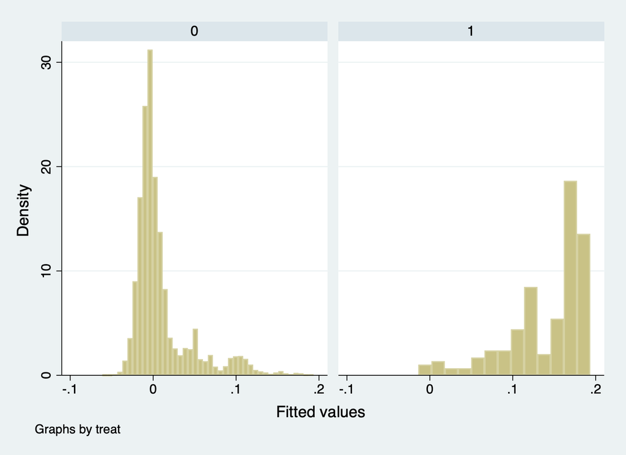

The min and max values of the propensity score(drop) - treat=1: 0.1018124 and 0.1934806.

The min and max values of the propensity score(drop) - treat=0: 0.100047 and 0.1934767.

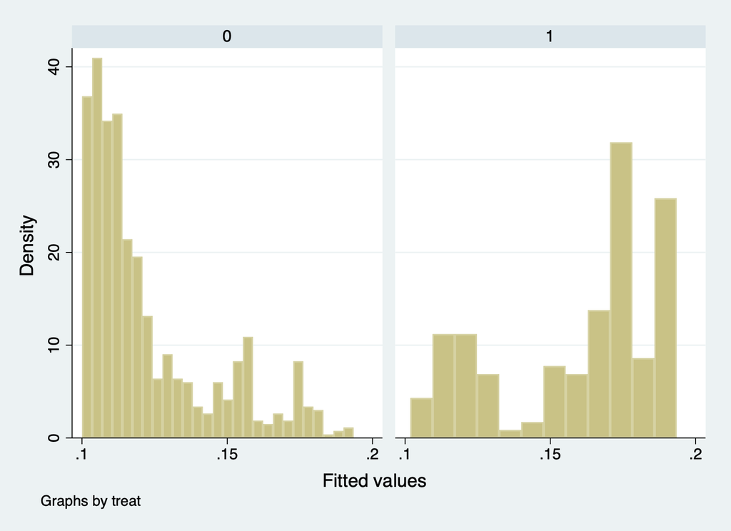

- OLS with cubic for each variable

The min and max values of the propensity score - treat=1: -0.0152693 and 0.20838.

The min and max values of the propensity score - treat=0: -0.0535283 and 0.2072448.

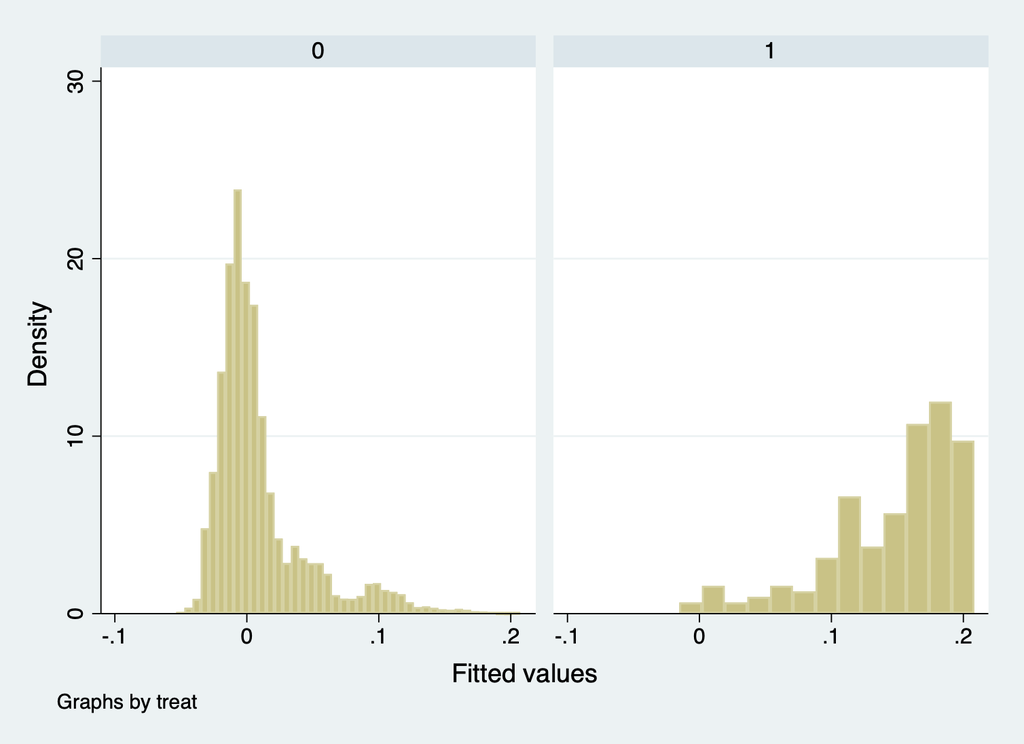

The min and max values of the propensity score(drop) - treat=1: 0.1011328 and 0.20838.

The min and max values of the propensity score(drop) - treat=0: 0.1000906 and 0.2072448.

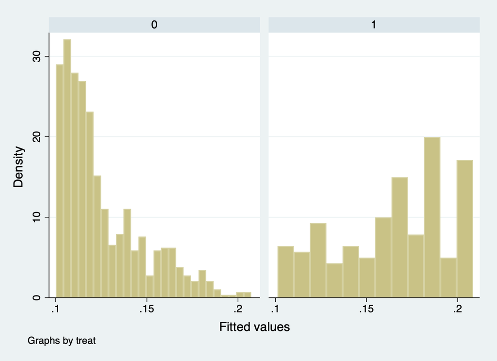

- Logit with quadratic for each variable

The min and max values of the propensity score - treat=1: 0.0007372 and 0.9015551.

The min and max values of the propensity score - treat=0: 2.83e-10 and 0.8915.

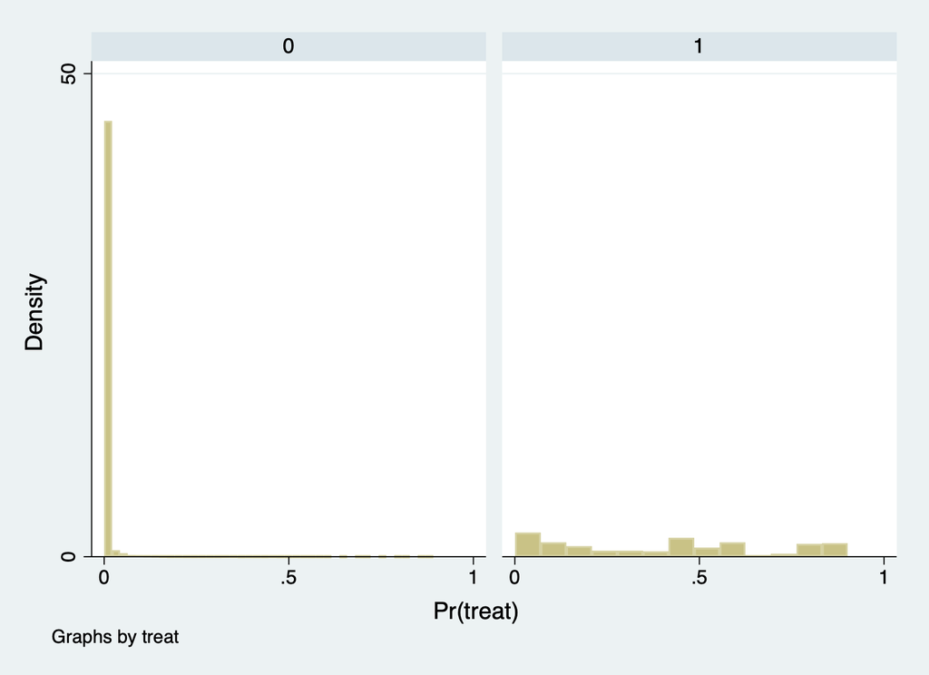

The min and max values of the propensity score(drop) - treat=1: 0.1065083 and 0.8996394.

The min and max values of the propensity score(drop) - treat=0: 0.1002043 and 0.8915.

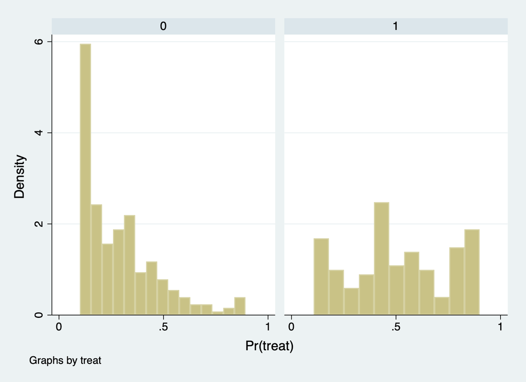

- Logit with cubic for each variable

The min and max values of the propensity score - treat=1: 0.0011628 and 0.9226575.

The min and max values of the propensity score - treat=0: 5.76e-09 and 0.9151357.

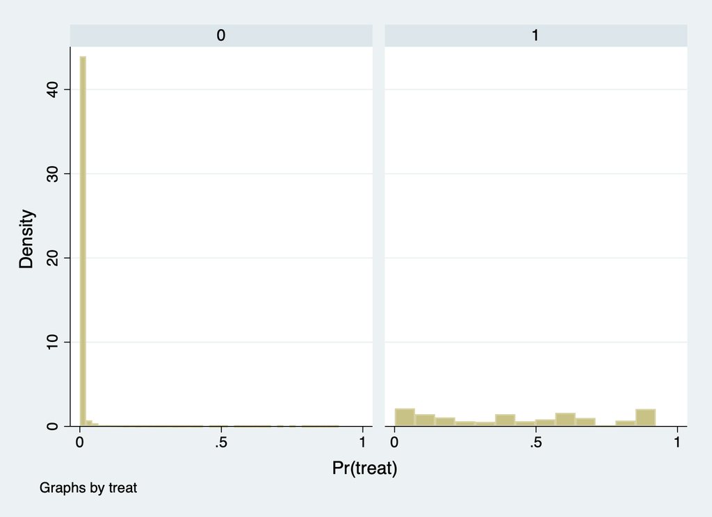

The min and max values of the propensity score(drop) - treat=1: 0.1062628 and 0.8985353.

The min and max values of the propensity score(drop) - treat=0: 0.100147 and 0.8770798.

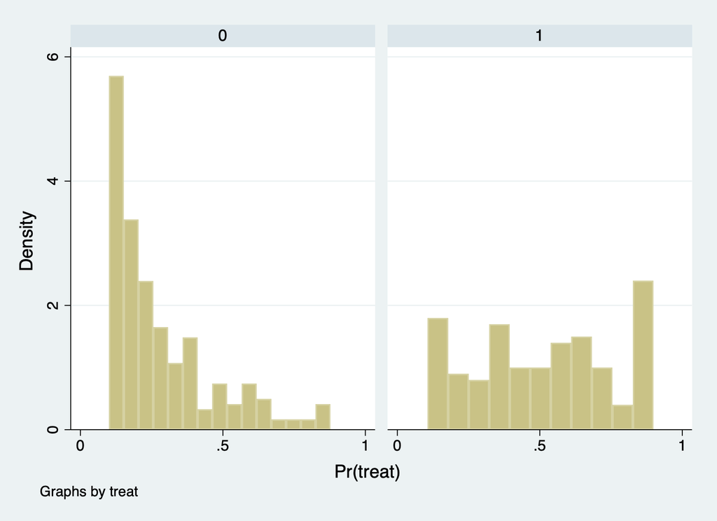

- Compared with results

According to our results (after we drop the propensity score less than 0.1 and larger than 0.9), our ATT for OLS with quadratic variables are -$4047 (non-normalization) and -$4967 (norm), and ATT for OLS with cubic variables are -$2254 (non-normalization) and -$3918 (norm). In addition, our ATT for logit with quadratic variables are $1101 (non-normalization) and $1246 (norm), and ATT for logit with cubic variables are $1744 (non-normalization) and $1635 (norm).

Compared with results from mixtape, if we use different model to estimate and trim them by different threshold and weighting scheme, We can find those values are obvious different.